# DV8&9HW

Author

Carter Wyatt

```r
library(tidyverse)
library(moderndive)
library(infer)
```

## Chapter 8

## Question 1

```r
set.seed(1108)

poll <- tibble(
  vote_gop = rbinom(n = 1000,
                    size = 1,
                    prob = .53))
```

```r
percentile_95 <- poll |>
  get_confidence_interval(level = 0.95, type = "percentile")
percentile_95
```

```
# A tibble: 1 × 2
  lower_ci upper_ci
     <dbl>    <dbl>
1        0        1
```

```r
percentile_95 |>
  rep_sample_n(size = 1, replace = TRUE, reps = 1000) %>%
  group_by(replicate) |>
  summarize(gop_share = mean(year))
```

```
# A tibble: 1,000 × 2
   replicate gop_share
       <int>     <dbl>
 1         1        NA
 2         2        NA
 3         3        NA
 4         4        NA
 5         5        NA
 6         6        NA
 7         7        NA
 8         8        NA
 9         9        NA
10        10        NA
# ℹ 990 more rows
```

```r
confidence <- quantile(c(.025, .975))


print(confidence)
```

```
    0%    25%    50%    75%   100%
0.0250 0.2625 0.5000 0.7375 0.9750
```

What is the estimated confidence interval?

```r
bootstrap_95 <- poll |>
  specify(response = vote_gop) |>
  generate(reps = 1000, type = "bootstrap") |>
  calculate(stat = "mean")

get_ci(bootstrap_95, level = 0.95)
```

```
# A tibble: 1 × 2
  lower_ci upper_ci
     <dbl>    <dbl>
1    0.482    0.548
```

What is the estimated confidence interval?

How similar are the two confidence intervals you calculated? Why aren’t they *exactly* the same?

## History of Rap

```r
rap_poll <- read_csv("https://raw.githubusercontent.com/rfordatascience/tidytuesday/master/data/2020/2020-04-14/polls.csv")
```

```r
filter_rap <- rap_poll |>
  filter(rank == 1)

glimpse(filter_rap)
```

```
Rows: 107
Columns: 9
$ rank            <dbl> 1, 1, 1, 1, 1, 1, 1, 1, 1, 1, 1, 1, 1, 1, 1, 1, 1, 1, …
$ title           <chr> "Terminator X To The Edge of Panic", "Players", "Rappe…
$ artist          <chr> "Public Enemy", "Slum Village", "Sugarhill Gang", "The…
$ gender          <chr> "male", "male", "male", "male", "male", "male", "male"…
$ year            <dbl> 1998, 1997, 1979, 1994, 2003, 1982, 1989, 1992, 1982, …
$ critic_name     <chr> "Joseph Abajian", "Biba Adams", "Dart Adams", "Insanul…
$ critic_rols     <chr> "Fat Beats", "Critic", "Critic", "Genius", "Critic", "…
$ critic_country  <chr> "US", "US", "US", "US", "Nigeria", "US", "US", "US", "…
$ critic_country2 <chr> NA, NA, NA, NA, NA, NA, NA, NA, NA, NA, NA, NA, NA, NA…
```

## Question 2

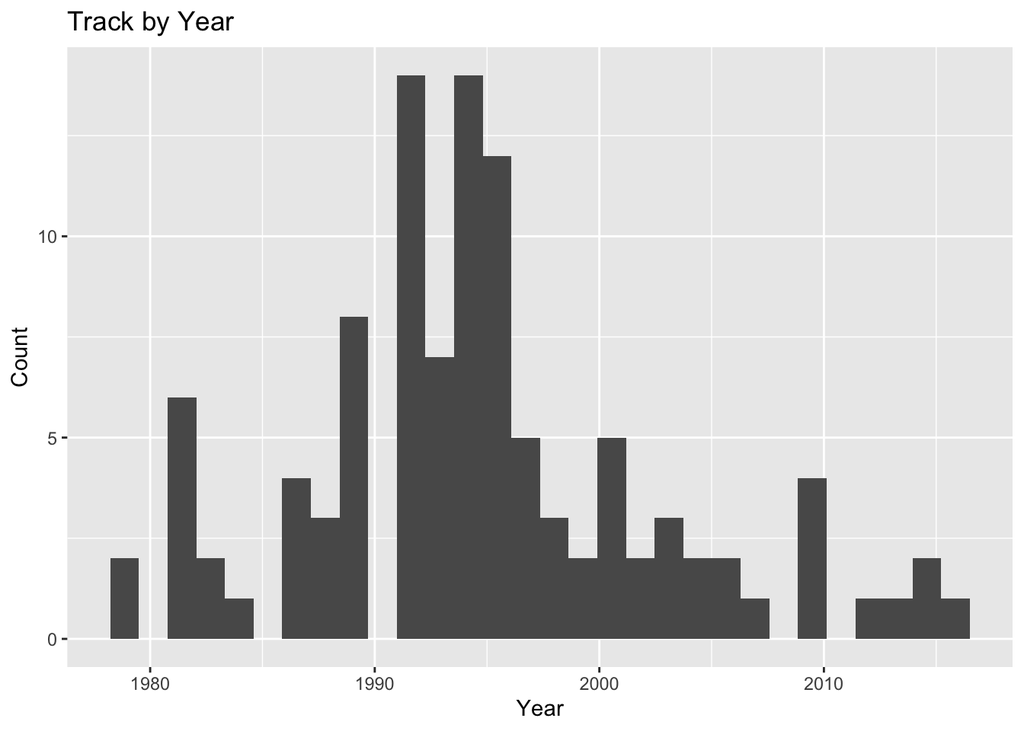

```r
filter_rap |>
  ggplot(
    aes(x = year)
  ) +
  geom_histogram() +
  labs(x = "Year", y = "Count", title = "Track by Year", alpha = 0.2)
```

What is the year of the most commonly named favorite track in this critic poll?

1994 AND 1992 both have the most commonly named favorite track.

How many critics named a track from this year?

## Question 3

```r
critics <- filter_rap |>
  specify(response = year) |>
  generate(reps = 1000, type = "bootstrap") |>
  calculate(stat = "mean")

get_ci(critics, level = 0.95)
```

```
# A tibble: 1 × 2
  lower_ci upper_ci
     <dbl>    <dbl>
1    1993.    1996.
```

Report the upper and lower bound of this interval to the nearest year.

Lower = 1993

Upper = 1996

## Question 4

```r
critics |>
  rep_sample_n(size = 25, replace = TRUE, reps = 1000) %>%
  group_by(stat) |>
  summarize(rank = mean(rank))
```

```
# A tibble: 326 × 2
    stat  rank
   <dbl> <dbl>
 1 1993.    NA
 2 1993.    NA
 3 1993.    NA
 4 1993.    NA
 5 1993.    NA
 6 1993.    NA
 7 1993.    NA
 8 1993.    NA
 9 1993.    NA
10 1993.    NA
# ℹ 316 more rows
```

```r
critics <- quantile(c(.025, .975))

print(critics)
```

```
    0%    25%    50%    75%   100%
0.0250 0.2625 0.5000 0.7375 0.9750
```

How does the width of this confidence interval compare to the width of the confidence interval when we use the full sample of 107?

The width of this confidence interval should be smaller because 25 is less than 107 and should be more precise and accurate.

## Chapter 9

```r
pl_data <- read_csv("https://raw.githubusercontent.com/vaiseys/dav-course/main/Data/premier_league.csv")
glimpse(pl_data)
```

```
Rows: 380
Columns: 4
$ home_team  <chr> "Bournemouth", "Chelsea", "Everton", "Leicester", "Man Unit…
$ away_team  <chr> "Aston Villa", "Swansea", "Watford", "Sunderland", "Tottenh…
$ score_diff <dbl> -1, 0, 0, 2, 1, -2, -2, 0, -1, -3, -1, -3, -2, 2, 0, 0, -1,…
$ result     <chr> "aw", "d", "d", "hw", "hw", "aw", "aw", "d", "aw", "aw", "a…
```

## Question 5

```r
pl_data |>
  filter(result == "hw") |>
  summarise(proportion_HomeW = n() / nrow(pl_data))
```

```
# A tibble: 1 × 1
  proportion_HomeW
             <dbl>
1            0.413
```

## Question 6

```r
set.seed(22)

sampled_proportions <- c()

for (i in 1:1000) {

  sampled_results <- sample(c("aw", "hw" , "d"),
                            size = 380,
                            replace = TRUE,
                            prob = c(1/3,1/3,1/3))
  prop <- sum(sampled_results == "hw")/380
  sampled_proportions[i] <- prop

}
```

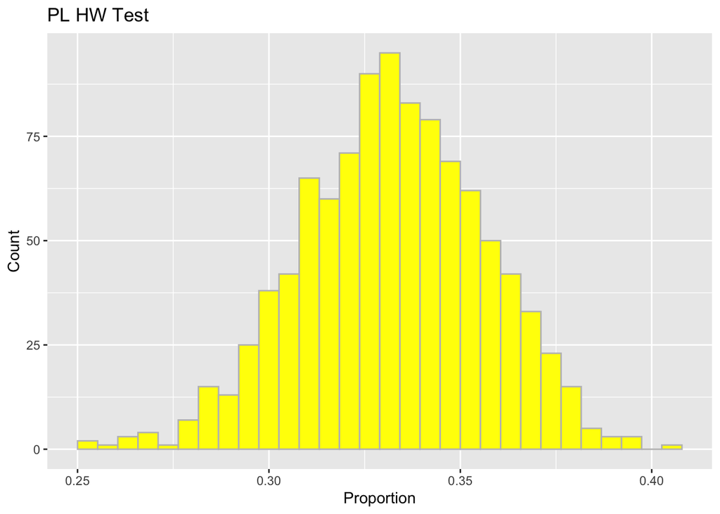

```r
hw_1 <- data.frame(proportions = sampled_proportions)
ggplot(hw_1,
mapping = aes(x = proportions)
) + geom_histogram(fill = "yellow", color = "grey") +
  labs(x = "Proportion", y = "Count", title = "PL HW Test")
```

## Question 7

In this scenario, what would be the null hypothesis and the alternative hypothesis? Provide enough detail so that I know you understand.

The null hypothesis would be proportions because there will be no change, and the alternative hypothesis would be the sampled proportions.

## Question 8

What would a p-value mean in this example?

The P value would mean the likelyhood of the data actually being sampled and proportioned.